# Reasons for Innovating

## How have the main reasons for innovating changed since 2021?

```r
catalyst_all_years <- import(here("data/longitudinal", "longitudinal_data.csv")) %>%
  select(year, school_id, starts_with("catalyst")) %>%
  filter(year == 2021 | year == 2024)

catalyst_all_years_long <- catalyst_all_years %>%
  select(-contains("_other"), -contains("_key")) %>%
  pivot_longer(cols = contains("catalyst"),
               names_to = "catalyst",
               values_to = "selected",
               names_prefix = "catalyst_")
```

From Cycle 2, I had created this graph.

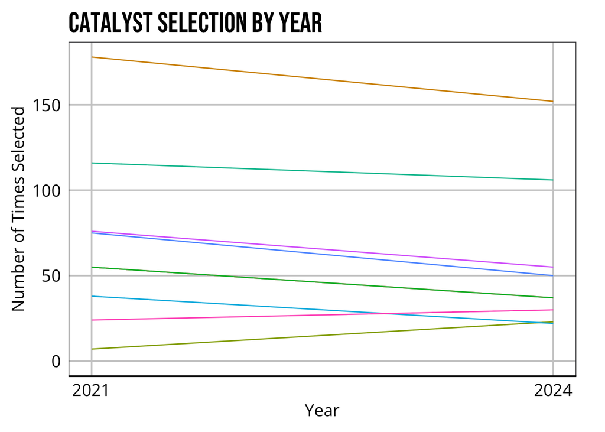

```r
library(ggrepel)
label_positions <- catalyst_all_years_long %>%
  group_by(catalyst) %>%
  summarize(year = 2021, selected = first(selected))

catalyst_all_years_long <- catalyst_all_years_long %>%
  group_by(catalyst, year, selected) %>%
  filter(selected == 1) %>%
  select(-selected) %>%
  summarize(selected = n())

catalyst_all_years_long %>%
  ggplot(aes(x = year, y = selected, color = catalyst)) +
  geom_line() +
  geom_text_repel(data = label_positions, aes(label = catalyst)) +
  scale_x_continuous(breaks = c(2021, 2024)) +
  labs(x = "Year",
       y = "Number of Times Selected",
       title = "Catalyst Selection by Year") +
  theme(legend.position = "none")
```

How many schools selected just one catalyst in particular?

```r
one_cat <- catalyst_all_years %>%
  select(-contains("_other"), -contains("_key")) %>%
  mutate(cat_select = rowSums(across(3:11))) %>%
  filter(cat_select == 1) %>%
  pivot_longer(cols = contains("catalyst"),
               names_to = "catalyst",
               values_to = "selected",
               names_prefix = "catalyst_") %>%
  filter(selected == 1) %>%
  group_by(year, catalyst) %>%
  summarise(count = n())
```

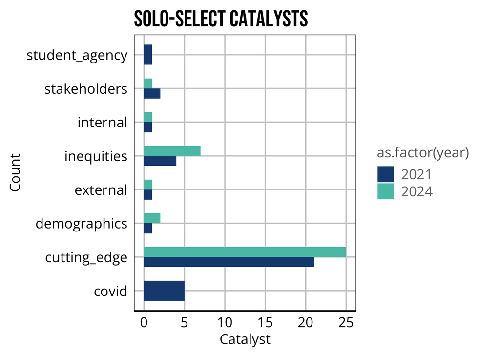

```r
one_cat %>%
  ggplot(aes(x = count, y = catalyst, fill = as.factor(year))) +
  geom_col(position = "dodge") +
  scale_fill_manual(values = transcend_cols) +
  labs(title = "Solo-Select Catalysts",
       x = "Catalyst",
       y = "Count",
       legend = "Year")
```

## How often have schools that responded in both 2021 and 2024 changed their key catalysts?

```r
cat_by_year <- catalyst_all_years %>%
  select(year, school_id, starts_with("catalyst_key"), -contains("_other")) %>%
  pivot_longer(cols = contains("catalyst"),
               names_to = "catalyst_key",
               values_to = "selected",
               names_prefix = "catalyst_key_") %>%
  pivot_wider(names_from = year,
              values_from = selected) %>%
  na.omit() %>%  #omit schools that only answered one year
  mutate(selected = case_when(`2021` == 0 & `2024` == 0 ~ "neither year",
                            `2021` == 0 & `2024` == 1 ~ "added",
                            `2021` == 1 & `2024` == 0 ~ "dropped",
                            `2021` == 1 & `2024` == 1 ~ "both years")) %>%
  group_by(catalyst_key, selected) %>%
  summarise(n = n())
```

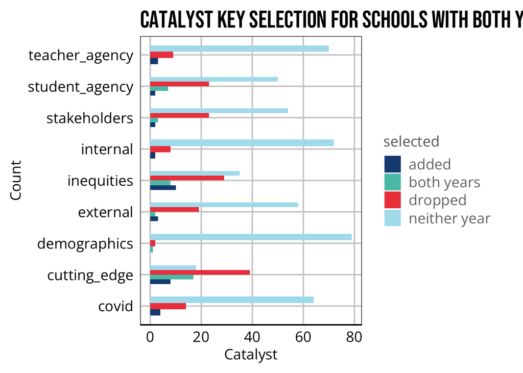

```r
cat_by_year %>%
  ggplot(aes(x = n, y = catalyst_key, fill = selected)) +
  geom_col(position = "dodge") +
  scale_fill_manual(values = transcend_cols) +
  labs(title = "Catalyst Key Selection for Schools with Both Years of Data",
       x = "Catalyst",
       y = "Count",
       legend = "Status")
```

This is from Cycle 2. What if we looked at schools who only selected one catalyst?

```r
one_cat_change <- catalyst_all_years %>%
  select(-contains("_other"), -contains("_key")) %>%
  mutate(cat_select = rowSums(across(3:11))) %>%
  filter(cat_select == 1) %>%
  pivot_longer(cols = contains("catalyst"),
               names_to = "catalyst",
               values_to = "selected",
               names_prefix = "catalyst_") %>%
  filter(selected == 1)
```

## For leaders who were concerned about future sustainability, what reasons did they cite for their concern and did these reasons differ across schools?

2024 only

```r
barriers <- full %>%
  select(school_id, starts_with("barrier"))
```

First, am curious how the free response category responded. I generated a wordcloud of these for barriers below.

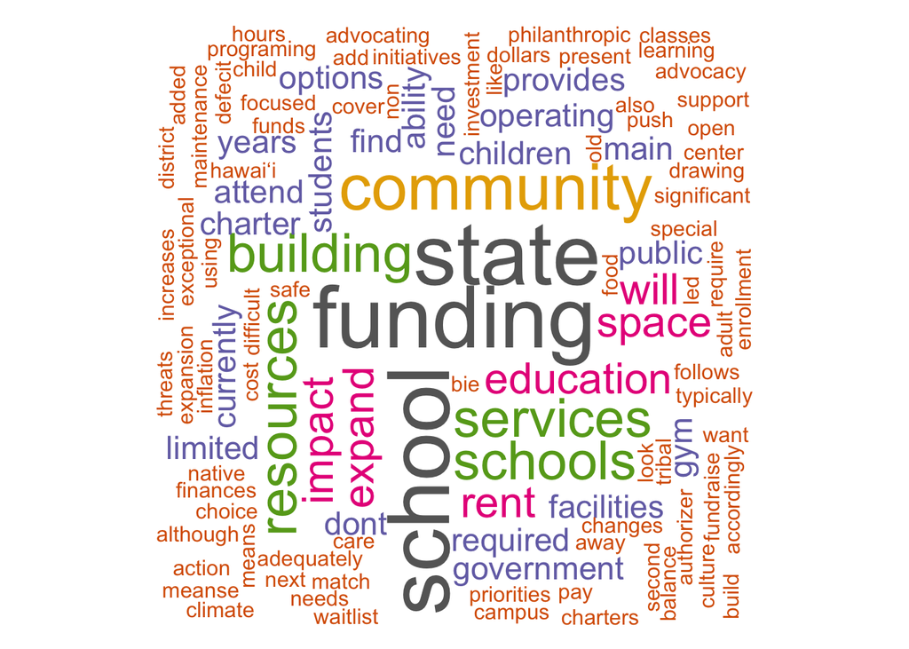

```r
library(wordcloud)
library(tm)

responses <- barriers$barrier_other_text

# Create a text corpus
corpus <- Corpus(VectorSource(responses))

# Text preprocessing
corpus <- tm_map(corpus, content_transformer(tolower))  # Convert to lower case
corpus <- tm_map(corpus, removePunctuation)             # Remove punctuation
corpus <- tm_map(corpus, removeNumbers)                 # Remove numbers
corpus <- tm_map(corpus, removeWords, stopwords("english"))  # Remove stopwords
corpus <- tm_map(corpus, stripWhitespace)               # Strip whitespace

# Create a document-term matrix
dtm <- TermDocumentMatrix(corpus)

# Convert the matrix to a dataframe
matrix <- as.matrix(dtm)
word_freqs <- sort(rowSums(matrix), decreasing=TRUE)
data <- data.frame(word=names(word_freqs), freq=word_freqs)

# Generate the wordcloud
set.seed(1234) # For reproducibility
wordcloud(words = data$word, freq = data$freq, min.freq = 1,
          max.words=200, random.order=FALSE, rot.per=0.35,
          colors=brewer.pal(8, "Dark2"))
```

While we’re here, I’m also including a wordcloud for the catalysts for innovation here.

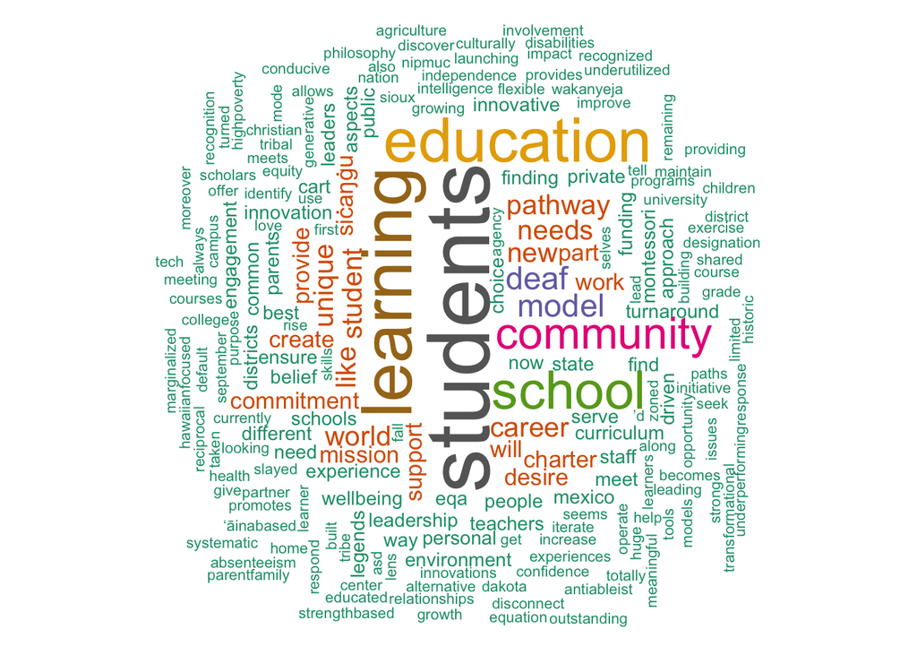

```r
responses <- full$catalyst_other_text

# Create a text corpus
corpus <- Corpus(VectorSource(responses))

# Text preprocessing
corpus <- tm_map(corpus, content_transformer(tolower))  # Convert to lower case
corpus <- tm_map(corpus, removePunctuation)             # Remove punctuation
corpus <- tm_map(corpus, removeNumbers)                 # Remove numbers
corpus <- tm_map(corpus, removeWords, stopwords("english"))  # Remove stopwords
corpus <- tm_map(corpus, stripWhitespace)               # Strip whitespace

# Create a document-term matrix
dtm <- TermDocumentMatrix(corpus)

# Convert the matrix to a dataframe
matrix <- as.matrix(dtm)
word_freqs <- sort(rowSums(matrix), decreasing=TRUE)
data <- data.frame(word=names(word_freqs), freq=word_freqs)

# Generate the wordcloud
set.seed(1234) # For reproducibility
wordcloud(words = data$word, freq = data$freq, min.freq = 1,
          max.words=200, random.order=FALSE, rot.per=0.35,
          colors=brewer.pal(8, "Dark2"))
```

Back to barriers –

For the rest of the options, here is what leaders selected.

```r
barriers <- barriers %>%
  select(-contains("_other")) %>%
  pivot_longer(cols = contains("barrier"),
               names_to = "barrier",
               values_to = "selected",
               names_prefix = "barrier_") %>%
  filter(selected == 1) %>%
  group_by(barrier) %>%
  summarize(n = n())
```

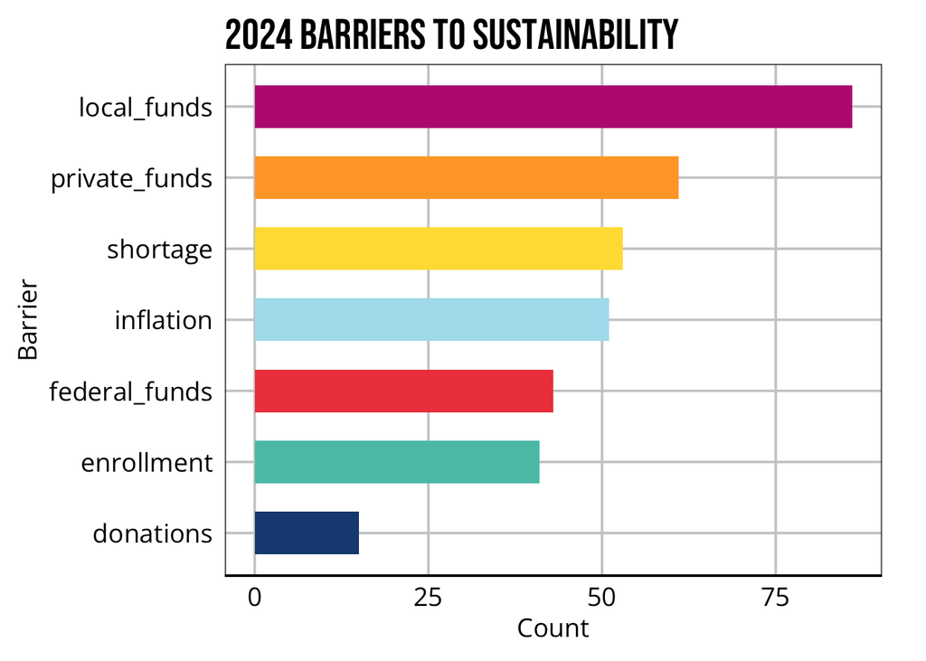

```r
barriers %>%
  ggplot(aes(reorder(barrier, n), n)) +
  geom_col(aes(fill = barrier)) +
  scale_fill_manual(values = c(transcend_cols, transcend_cols2)) +
  labs(title = "2024 Barriers to Sustainability",
       x = "Barrier",
       y = "Count") +
  theme(legend.position = "none") +
  coord_flip()
```